# SBD Strength Accumulation Analysis Project

I have logged nearly every workout from the past three years since I began taking weightlifting training seriously.

Most sets completed are not themselves single rep maxes of course, but one rep max strength levels are estimated by using the Epley, Brzycki, and Lombardi formulas and then taking an average of the three.

This process is flawed as no accounting for proximity to failure such as reps left in reserve on a given set is included in the data. In the future, tracking rate of perceived exertion to estimate reps left in reserve would add value to the analysis and potentially contribute to a better understanding of training cycling leading to strength gains, fatigue accumulation, and preparedness to perform single rep maxes.

*Epley Formula: 1RM = weight lifted × (1 + 0.0333 × number of reps)*

*Lombardi Formula: 1RM = weight lifted × (number of reps)^.1*

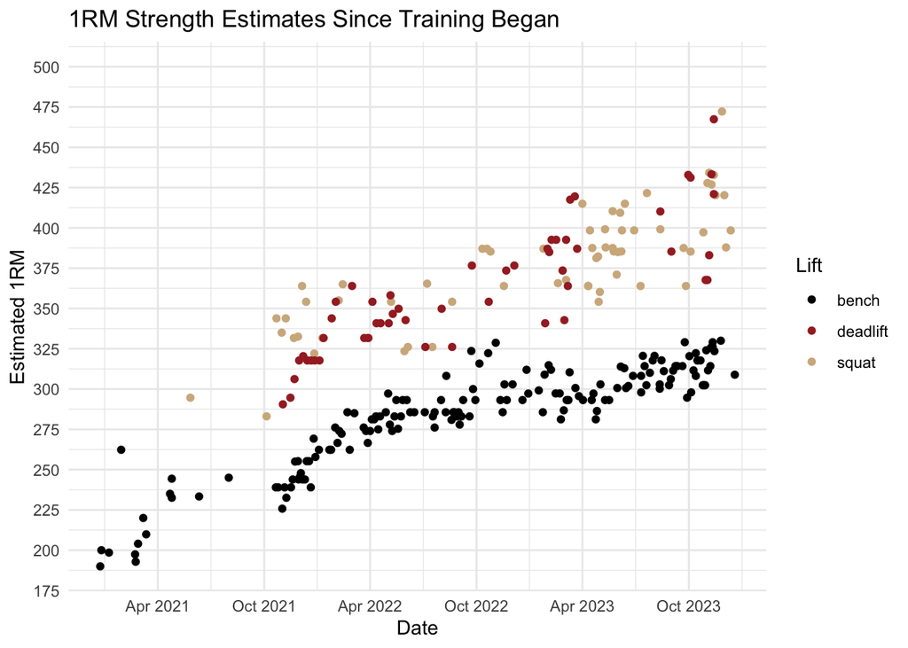

Two things stand out immediately with this chart  
1. All three lifts increased over time at a fairly consistent rate  
2. Bench press training frequency was much higher than that of squat or deadlift

To iterate on that graph, let’s add an indicator for two major training blocks I completed, the Candito and Nippard programs. Also, the trend line is fairly clear in the raw scatterplot data, but an loess y / x trend line helps to show how the slope of the lines change over time.

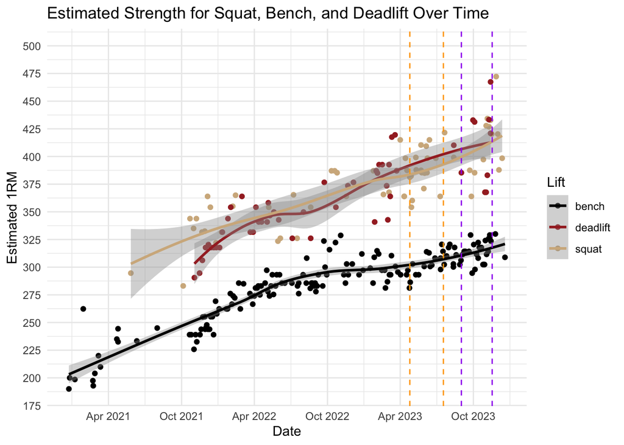

Now, an ARIMA forecasting model is added to estimate expected values for bench press over the next year. This model is essentially trying to capture all of the noise, as not all sessions are at or particularly near a true 1RM equivalency, the model attempts to capture all such training numbers.

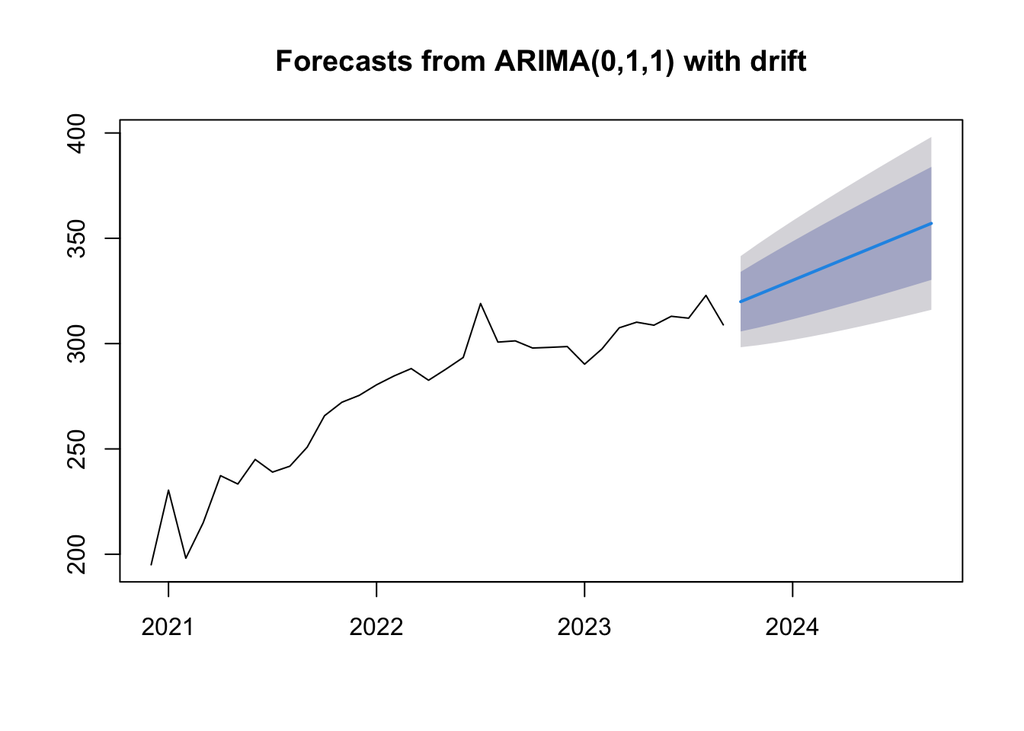

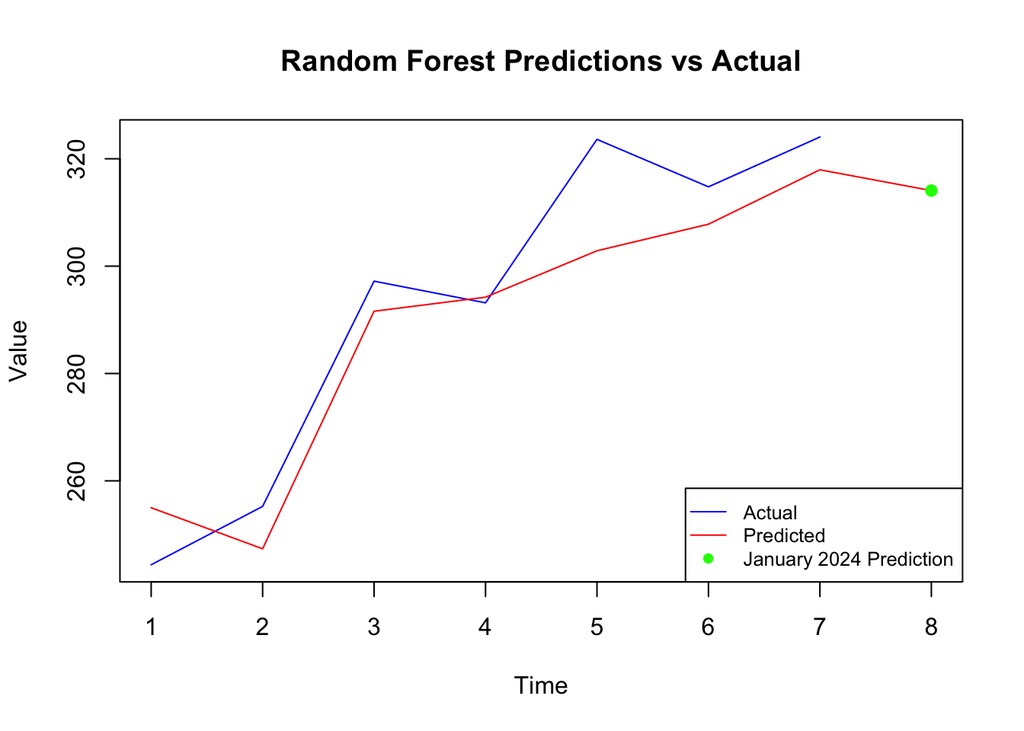

The random forest model predicts a decline in 1RM on bench press for January 2024. It is important to keep in mind that I do not attempt a true 1RM every month, nor do I necessarily hit a higher rep set that would convert to a similarly high number every month. For that reason, the model is not necessarily performing poorly by under-predicting, as it is possible that the randomness inherent in my training sessions could produce such an outcome.

Below is a chart showing the best lift from each category to date.

| Date | Weight | Rep | Epley | Brzycki | Lombardi | Lift | Average |
| --- | --- | --- | --- | --- | --- | --- | --- |
| 2023-11-27 | 420 | 4 | 475.94 | 458.22 | 482.45 | squat | 472.2 |
| 2023-11-13 | 375 | 8 | 474.9 | 465.61 | 461.68 | deadlift | 467.4 |
| 2023-11-25 | 330 | 1 | 330 | 330 | 330 | bench | 330 |